# Project 1

David Quarshie

8/30/2018

# Principles of Data Visualization and Introduction to ggplot2

```r
if(!require('ggplot2')) install.packages('ggplot2')
if(!require('dplyr')) install.packages('dplyr')
if(!require('scales')) install.packages('scales')
```

## Intro

I have provided you with data about the 5,000 fastest growing companies in the US, as compiled by Inc. magazine. lets read this in:

```r
inc <- read.csv("https://raw.githubusercontent.com/charleyferrari/CUNY_DATA_608/master/module1/Data/inc5000_data.csv", header= TRUE)
```

And lets preview this data:

```r
head(inc,5)
```

|  | Rank | Name | Growth_Rate | Revenue | Industry | Employees | City | State |
| --- | --- | --- | --- | --- | --- | --- | --- | --- |
| 1 | 1 | Fuhu | 421.48 | 1.179e+08 | Consumer Products & Services | 104 | El Segundo | CA |
| 2 | 2 | FederalConference.com | 248.31 | 4.960e+07 | Government Services | 51 | Dumfries | VA |
| 3 | 3 | The HCI Group | 245.45 | 2.550e+07 | Health | 132 | Jacksonville | FL |
| 4 | 4 | Bridger | 233.08 | 1.900e+09 | Energy | 50 | Addison | TX |
| 5 | 5 | DataXu | 213.37 | 8.700e+07 | Advertising & Marketing | 220 | Boston | MA |

```r
summary(inc)
```

```
      Rank                          Name       Growth_Rate         Revenue
 Min.   :   1   (Add)ventures         :   1   Min.   :  0.340   Min.   :2.000e+06
 1st Qu.:1252   @Properties           :   1   1st Qu.:  0.770   1st Qu.:5.100e+06
 Median :2502   1-Stop Translation USA:   1   Median :  1.420   Median :1.090e+07
 Mean   :2502   110 Consulting        :   1   Mean   :  4.612   Mean   :4.822e+07
 3rd Qu.:3751   11thStreetCoffee.com  :   1   3rd Qu.:  3.290   3rd Qu.:2.860e+07
 Max.   :5000   123 Exteriors         :   1   Max.   :421.480   Max.   :1.010e+10
                (Other)               :4995
                         Industry      Employees                  City          State
 IT Services                 : 733   Min.   :    1.0   New York     : 160   CA     : 701
 Business Products & Services: 482   1st Qu.:   25.0   Chicago      :  90   TX     : 387
 Advertising & Marketing     : 471   Median :   53.0   Austin       :  88   NY     : 311
 Health                      : 355   Mean   :  232.7   Houston      :  76   VA     : 283
 Software                    : 342   3rd Qu.:  132.0   San Francisco:  75   FL     : 282
 Financial Services          : 260   Max.   :66803.0   Atlanta      :  74   IL     : 273
 (Other)                     :2358   NA's   :12        (Other)      :4438   (Other):2764
```

Think a bit on what these summaries mean. Use the space below to add some more relevant non-visual exploratory information you think helps you understand this data:

The summary of this data shows that a lot of these fast growing companies are in California and are in the IR services industry.

## Question 1

Create a graph that shows the distribution of companies in the dataset by State (ie how many are in each state). There are a lot of States, so consider which axis you should use. This visualization is ultimately going to be consumed on a ‘portrait’ oriented screen (ie taller than wide), which should further guide your layout choices.

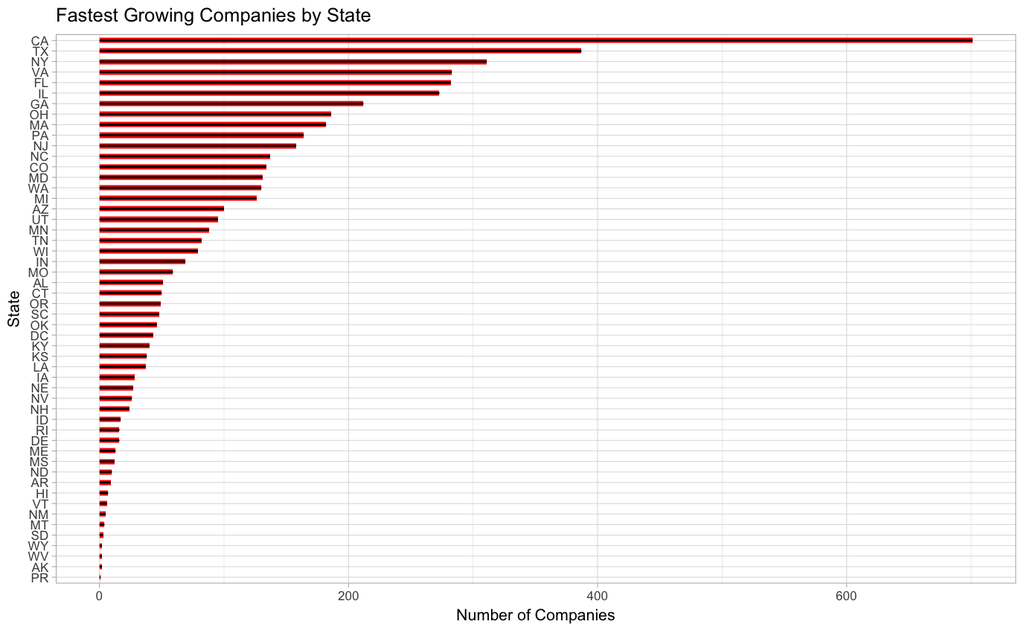

```r
data <- inc %>%
    group_by(State) %>%
    count()
ggplot(data, aes(x=reorder(State, n), y=n)) +
  geom_bar(stat="identity", width = 0.5, fill="red") +
  geom_segment(aes(x=State, xend=State, y=0, yend=n)) +
  coord_flip() +
  theme_light(8) +
      labs(title="Fastest Growing Companies by State",
         y="Number of Companies",
         x="State")
ggsave('Figure1.png')
```

## Quesiton 2

Lets dig in on the state with the 3rd most companies in the data set. Imagine you work for the state and are interested in how many people are employed by companies in different industries. Create a plot that shows the average and/or median employment by industry for companies in this state (only use cases with full data, use R’s `complete.cases()` function.) In addition to this, your graph should show how variable the ranges are, and you should deal with outliers.

```r
#Find which state has the 3rd most companies
filter(data, n == sort(data$n, T)[3])
```

| State | n |
| --- | --- |
| NY | 311 |

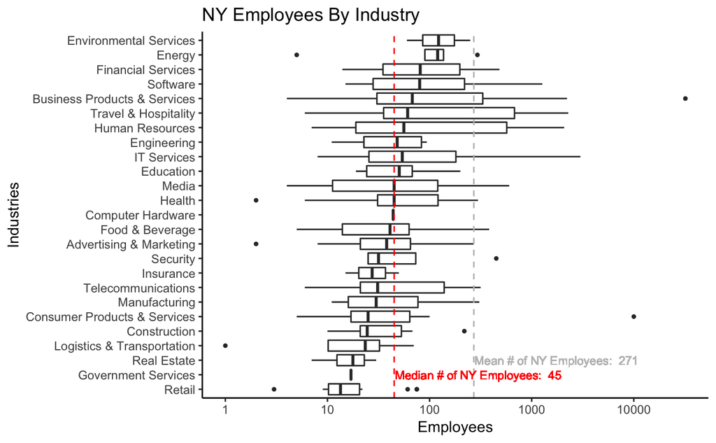

```r
#Create subset for NY
ny <- subset(inc, State=="NY")
ny <- ny[complete.cases(ny$Industry), ]
ny <- ny[complete.cases(ny$Employees), ]
med <- paste0("Median # of NY Employees:  ", median(ny$Employees))
avg <- paste0("Mean # of NY Employees:  ", round(mean(ny$Employees),0))
ggplot(ny, aes(x=reorder(Industry, Employees, FUN=median), y=Employees)) +
    geom_boxplot(outlier.shape = 20) +
    scale_y_continuous(trans = log10_trans(), limits = c(min(ny$Employees), max(ny$Employees))) +
    geom_hline(yintercept = median(ny$Employees),
               color="red",
               linetype="dashed") +
    geom_hline(yintercept = mean(ny$Employees),
               color="grey",
               linetype="dashed") +
    geom_text(aes(x=2, label=med, y = 300),
              size = 3,
              colour="red") +
    geom_text(aes(x=3, label=avg, y = 1750),
              size = 3,
              colour="grey") +
    labs(title="NY Employees By Industry",
         #subtitle="5000 Fastest Growing Companies by Industry",
         #caption="Source: Inc Magazine",
         y="Employees",
         x="Industries") +
    theme_classic() +
    coord_flip()
```

## Question 3

Now imagine you work for an investor and want to see which industries generate the most revenue per employee. Create a chart that makes this information clear. Once again, the distribution per industry should be shown.

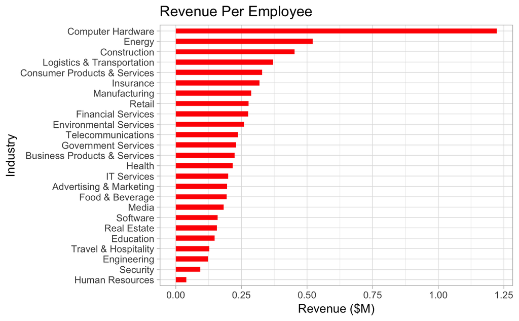

```r
rev <- inc[complete.cases(inc$Revenue), ]
rev <- rev[complete.cases(rev$Employees), ]
rev <- rev %>%
    group_by(Industry) %>%
    summarise(RevenuePer = sum(Revenue)/sum(Employees)/1000000)
ggplot(rev, aes(x=reorder(Industry, RevenuePer), y=RevenuePer)) +
    geom_bar(stat="identity", width=.5, fill="red")+
    labs(title="Revenue Per Employee",
         y="Revenue ($M)",
         x="Industry") +
    theme_light(12) +
    coord_flip()
```